# Geochemical Plots

Justin R. Jent

2026-10-21

The manager package provides a set of geochemical visualization functions for evaluating groundwater and surface water chemistry.

Currently supported plots include:

Piper diagrams Schoeller diagrams Stiff diagrams

These plots share a common data preparation workflow that ensures consistent analyte handling, unit standardization, and conversion to milliequivalents per liter (meq/L).

```r
data("gw_data")
dplyr::glimpse(gw_data)
```

```
#> Rows: 5,878
#> Columns: 6
#> $ location_id     <chr> "MW-2", "MW-2", "MW-2", "MW-2", "MW-2", "MW-2", "MW-2"…
#> $ sample_date     <dttm> 2008-10-28, 2008-10-28, 2008-10-28, 2008-10-28, 2008-…
#> $ analysis_result <dbl> 36.300, 18.900, 0.500, 24.900, 170.000, 0.290, 1.900, …
#> $ lt_measure      <chr> NA, NA, NA, NA, NA, NA, NA, NA, "<", NA, "<", "<", NA,…
#> $ default_unit    <chr> "mg/L", "mg/L", "mg/L", "mg/L", "mg/L", "mg/L", "ug/L"…
#> $ param_name      <chr> "Magnesium, dissolved", "Sodium, dissolved", "Potassiu…
```

Geochemical Plot Workflow All geochemical plotting functions follow the same processing pipeline.

1. Resolve analyte aliases to canonical analytes.
2. Validate analyte-unit consistency.
3. Standardize analytical units.
4. Convert concentrations to milliequivalents per liter (meq/L).
5. Transform data into plot-specific coordinates.
6. Render visualization.

This workflow allows plotting functions to accept either canonical analyte names or approved analyte aliases while maintaining consistent chemistry calculations.

Piper Diagram A Piper diagram is commonly used to classify water types and evaluate hydrochemical facies.

The plot is generated directly from the analytical data.

```
#> 21 analytes have no standard unit. Original reporting values and units were retained
#> ℹ cobalt dis, temperature celsius, specific conductance 25c, ph, solids, nitrate nitrogen, phosphorus,
#>   aluminum, uranium, groundwater elevation ref msl
```

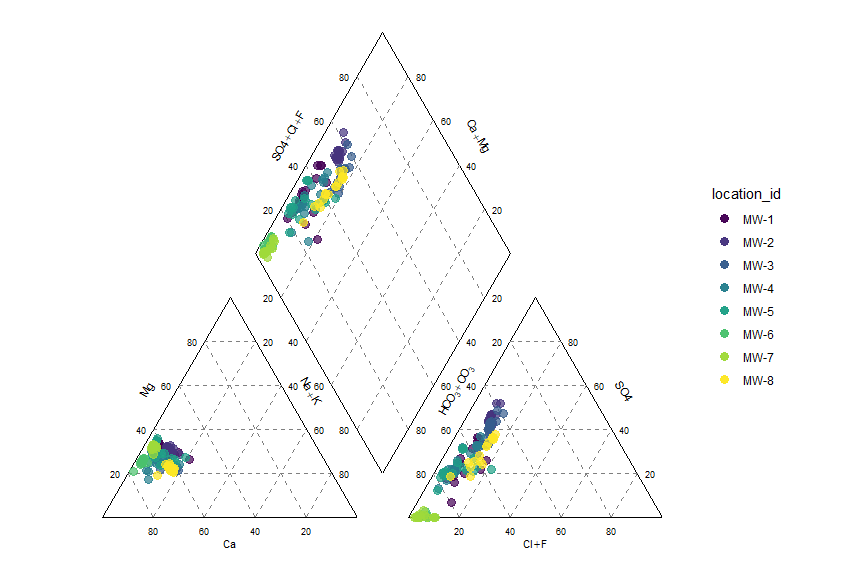

```r
gw_data %>%
  piper_plot()
```

Schoeller Diagram A Schoeller diagram displays major ion concentrations on a logarithmic scale and is useful for:

Comparing groundwater chemistry between wells Evaluating temporal trends Identifying mixing relationships Screening for anomalous chemistry

```
#> 21 analytes have no standard unit. Original reporting values and units were retained
#> ℹ cobalt dis, temperature celsius, specific conductance 25c, ph, solids, nitrate nitrogen, phosphorus,
#>   aluminum, uranium, groundwater elevation ref msl
```

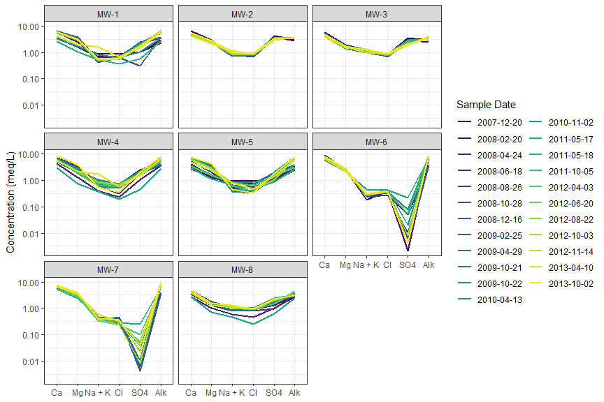

```r
gw_data %>%
  schoeller_plot()
```

```
#> 21 analytes have no standard unit. Original reporting values and units were retained
#> ℹ temperature celsius, specific conductance 25c, ph, solids, nitrate nitrogen, phosphorus, cobalt dis,
#>   aluminum, uranium, groundwater elevation ref msl
#> 21 analytes have no standard unit. Original reporting values and units were retained
#> ℹ temperature celsius, specific conductance 25c, ph, solids, nitrate nitrogen, phosphorus, cobalt dis,
#>   aluminum, uranium, groundwater elevation ref msl
```

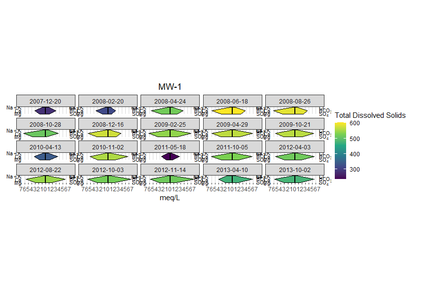

```r
gw_data %>%
  filter(location_id == "MW-1") %>%
  stiff_plot(scale_analyte = "Total Dissolved Solids")
```